# Classification Final Project DS 805: Statistical Learning

Carter Mercer, Jon Olson, Conor O’Regan

## Data

```r
df = read.csv("https://unh.box.com/shared/static/h2e0xzpfifrlc7cmxkw617gfg8g9zt3p.csv")
glimpse(df)
```

```
## Rows: 15,292
## Columns: 37
## $ X                                   <int> 1, 2, 3, 4, 5, 6, 7, 8, 9, 10, 11…
## $ Row                                 <int> 1, 2, 3, 4, 5, 6, 7, 8, 9, 10, 11…
## $ AgencyName                          <chr> "21ST CENTURY CHARTER SCH OF GARY…
## $ State                               <chr> "Indiana", "Pennsylvania", "Arizo…
## $ FallMembership_16_17                <int> 888, 961, 64, 2278, 1069, 629, 12…
## $ RevenueLocalSources_16_17           <dbl> 516000, 12717000, 47000, 363000, …
## $ RevenueGeneral_16_17                <dbl> 9342000, 12848000, 492000, 201980…
## $ RevenueStateSources_16_17           <dbl> 7563000, 40000, 440000, 17778000,…
## $ RevenueFederalSources_16_17         <int> 1263000, 91000, 5000, 2057000, 14…
## $ CurrentExpendituresSecEdu_16_17     <dbl> 7447000, 11940000, 481000, 184750…
## $ CurrentExpenditures_16_17           <dbl> 8637000, 12528000, 495000, 185050…
## $ RevenuePerPupil_16_17               <int> 10520, 13369, 7688, 8867, 11573, …
## $ RevenueLocalSourcesPerPupil_16_17   <int> 581, 13233, 734, 159, 458, 167, 1…
```

[output cut: 24 more lines]

```r
attach(df)
```

## Exploratory Data Analysis

#### Check for existence of NA’s (missing data)

```r
colSums(is.na(df))
```

```
##                                   X                                 Row
##                                   0                                   0
##                          AgencyName                               State
##                                   0                                   0
##                FallMembership_16_17           RevenueLocalSources_16_17
##                                   0                                   0
##                RevenueGeneral_16_17           RevenueStateSources_16_17
##                                   0                                   0
##         RevenueFederalSources_16_17     CurrentExpendituresSecEdu_16_17
##                                   0                                   0
##           CurrentExpenditures_16_17               RevenuePerPupil_16_17
##                                   0                                   0
##   RevenueLocalSourcesPerPupil_16_17   RevenueStateSourcesPerPupil_16_17
##                                   0                                   0
## RevenueFederalSourcesPerPupil_16_17                            AgencyID
##                                   0                                   0
##                    AgencyType_18_19             StartOfYearStatus_18_19
##                                   0                                   0
##              TotalStudentsAllGrades                  AmerIndAlaska0tive
##                                   0                                   0
##               Asian_AsianPacificIsl                            Hispanic
##                                   0                                   0
##                               Black                               White
##                                   0                                   0
##                 Hawaiian_PacificIsl                      TwoOrMoreRaces
##                                   0                                   0
##                 AmerIndAlaska0tive.              Asian_AsianPacificIsl.
##                                   0                                   0
##                           Hispanic.                              Black.
##                                   0                                   0
##                              White.                Hawaiian_PacificIsl.
##                                   0                                   0
##                     TwoOrMoreRaces.                    CountyName_18_19
##                                   0                                   0
##            UrbanCentricLocale_18_19                                Size
##                                   0                                   0
##                            Size_0_1
##                                   0
```

```r
summary(complete.cases(df))
```

```
##    Mode    TRUE
## logical   15292
```

```r
summary(df)
```

```
##        X              Row         AgencyName           State
##  Min.   :    1   Min.   :    1   Length:15292       Length:15292
##  1st Qu.: 3911   1st Qu.: 3911   Class :character   Class :character
##  Median : 7812   Median : 7812   Mode  :character   Mode  :character
##  Mean   : 7803   Mean   : 7803
##  3rd Qu.:11702   3rd Qu.:11702
##  Max.   :15589   Max.   :15589
##  FallMembership_16_17 RevenueLocalSources_16_17 RevenueGeneral_16_17
##  Min.   :     2       Min.   :1.000e+03         Min.   :6.600e+04
##  1st Qu.:   356       1st Qu.:1.507e+06         1st Qu.:4.805e+06
##  Median :   923       Median :4.923e+06         Median :1.281e+07
##  Mean   :  3189       Mean   :2.001e+07         Mean   :4.390e+07
##  3rd Qu.:  2538       3rd Qu.:1.565e+07         3rd Qu.:3.672e+07
##  Max.   :633621       Max.   :3.276e+09         Max.   :1.058e+10
##  RevenueStateSources_16_17 RevenueFederalSources_16_17
##  Min.   :1.000e+03         Min.   :1.000e+03
##  1st Qu.:2.206e+06         1st Qu.:2.860e+05
##  Median :6.146e+06         Median :7.660e+05
##  Mean   :2.053e+07         Mean   :3.374e+06
##  3rd Qu.:1.638e+07         3rd Qu.:2.174e+06
##  Max.   :6.646e+09         Max.   :1.146e+09
##  CurrentExpendituresSecEdu_16_17 CurrentExpenditures_16_17
##  Min.   :5.600e+04               Min.   :5.800e+04
##  1st Qu.:4.110e+06               1st Qu.:4.709e+06
##  Median :1.081e+07               Median :1.259e+07
##  Mean   :3.710e+07               Mean   :4.400e+07
##  3rd Qu.:3.104e+07               3rd Qu.:3.653e+07
##  Max.   :8.585e+09               Max.   :9.825e+09
##  RevenuePerPupil_16_17 RevenueLocalSourcesPerPupil_16_17
##  Min.   :   681        Min.   :     1
##  1st Qu.: 10965        1st Qu.:  2916
##  Median : 13330        Median :  5195
##  Mean   : 15617        Mean   :  7120
##  3rd Qu.: 17569        3rd Qu.:  9278
##  Max.   :579870        Max.   :435532
##  RevenueStateSourcesPerPupil_16_17 RevenueFederalSourcesPerPupil_16_17
##  Min.   :     1                    Min.   :     1
##  1st Qu.:  5000                    1st Qu.:   550
##  Median :  6731                    Median :   863
##  Mean   :  7331                    Mean   :  1166
```

[output cut: 36 more lines]

```
##
##  TwoOrMoreRaces.    CountyName_18_19   UrbanCentricLocale_18_19
##  Length:15292       Length:15292       Length:15292
##  Class :character   Class :character   Class :character
##  Mode  :character   Mode  :character   Mode  :character
##
##
##
##      Size              Size_0_1
##  Length:15292       Min.   :0.0000
##  Class :character   1st Qu.:0.0000
##  Mode  :character   Median :0.0000
##                     Mean   :0.3699
##                     3rd Qu.:1.0000
##                     Max.   :1.0000
```

#### Boxplots

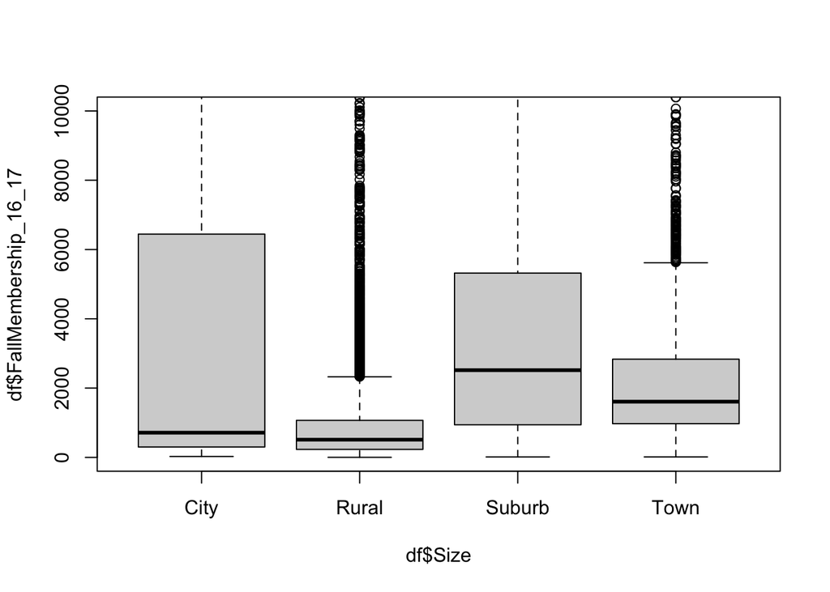

```r
boxplot(df$FallMembership_16_17 ~ df$Size, ylim = c(0,10000))
```

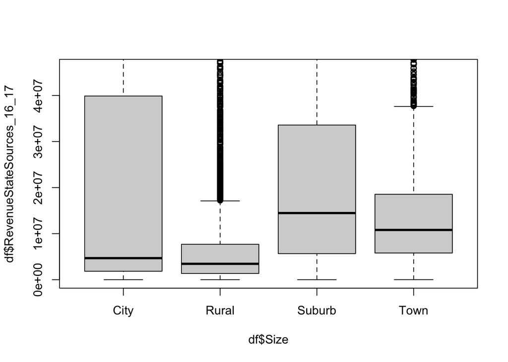

```r
boxplot(df$RevenueStateSources_16_17 ~ df$Size, ylim = c(0,46000000))
```

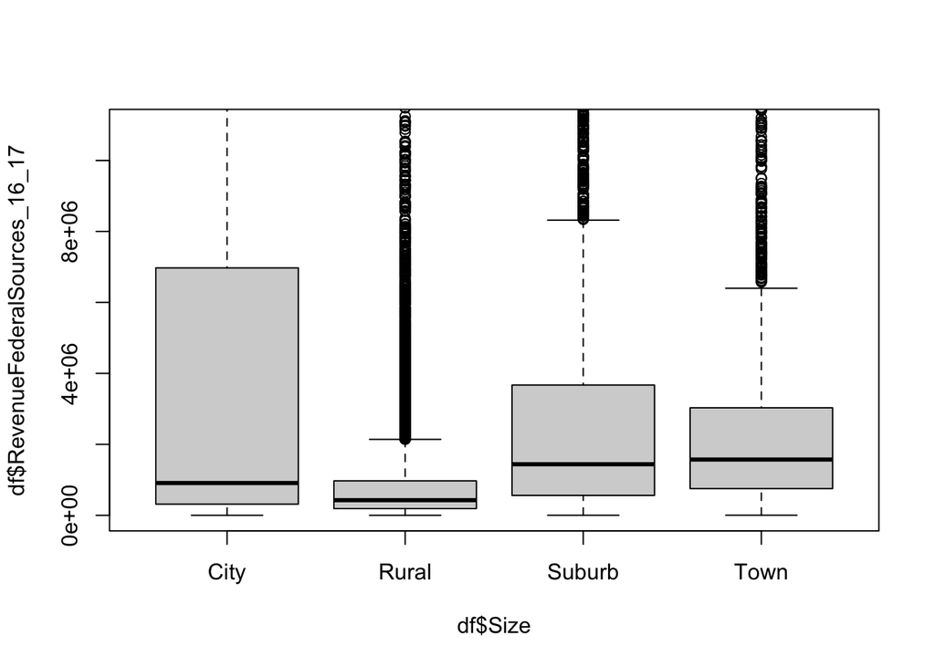

```r
boxplot(df$RevenueFederalSources_16_17 ~ df$Size, ylim = c(0,11000000))
```

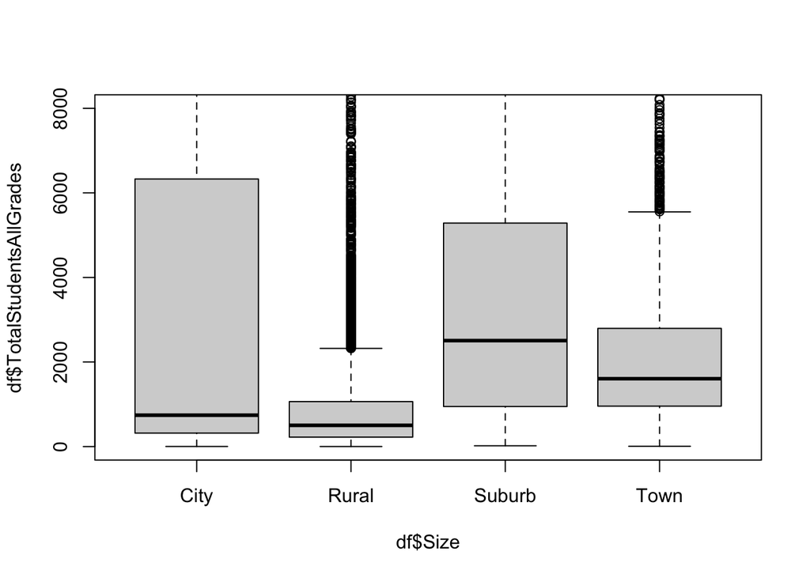

```r
boxplot(df$TotalStudentsAllGrades ~ df$Size, ylim = c(0,8000))
```

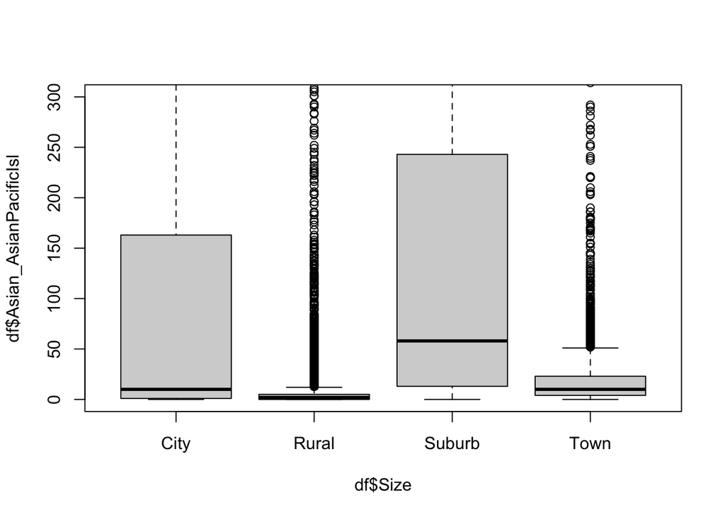

```r
boxplot(df$Asian_AsianPacificIsl ~ df$Size, ylim = c(0,300))
```

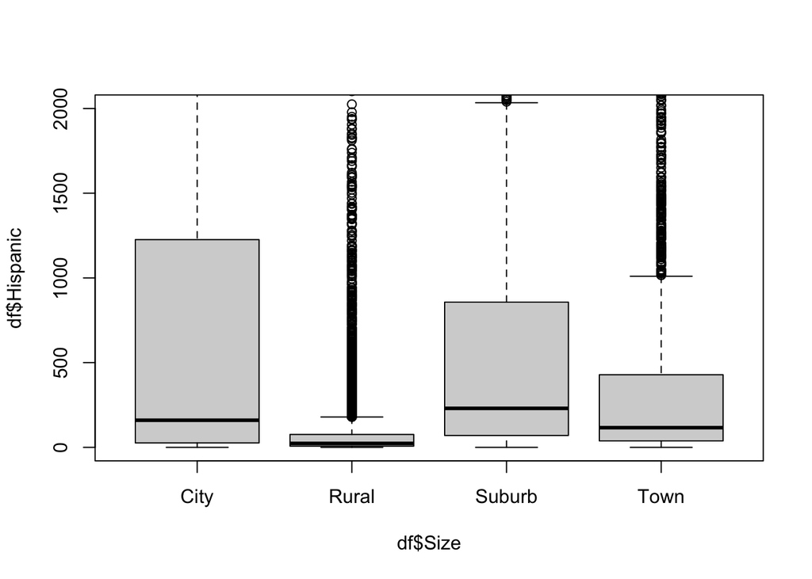

```r
boxplot(df$Hispanic ~ df$Size, ylim = c(0,2000))
```

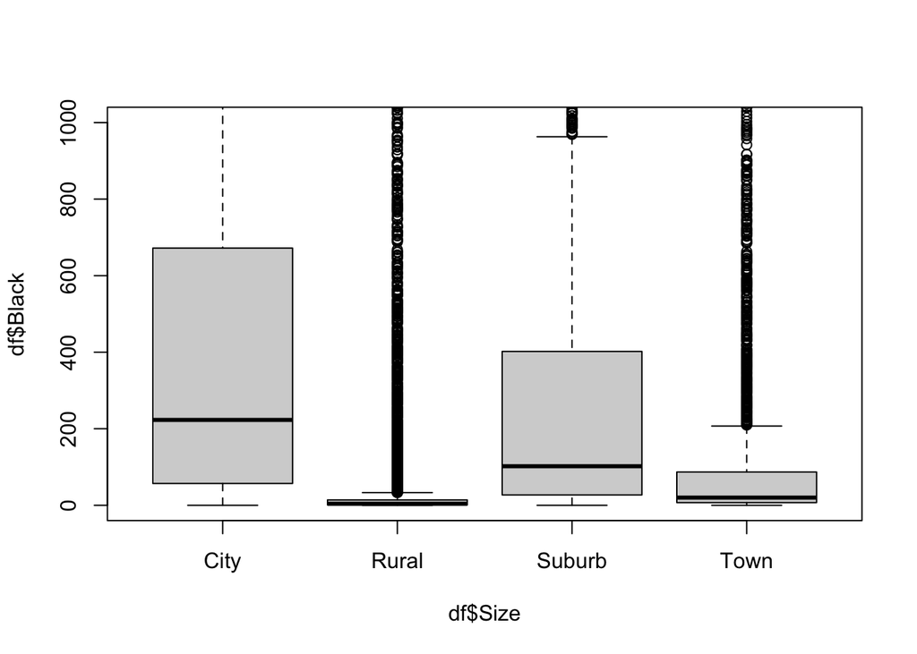

```r
boxplot(df$Black ~ df$Size, ylim = c(0,1000))
```

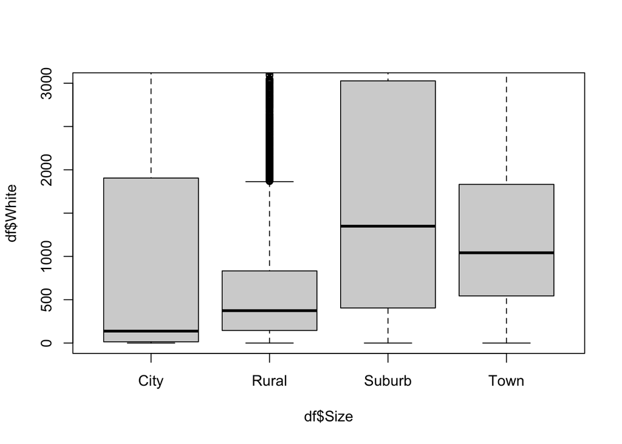

```r
boxplot(df$White ~ df$Size, ylim = c(0,3000))
```

#### Bar Charts

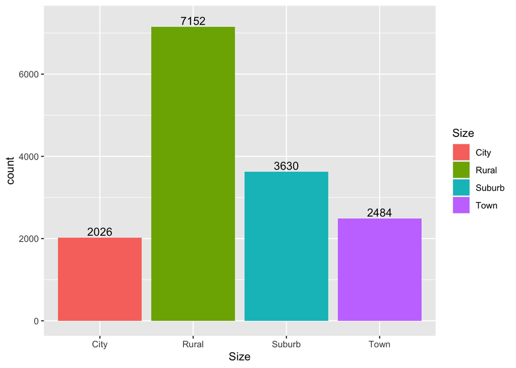

```r
totals = data.frame(table(df$Size))
ggplot(data=df, aes(x= Size, fill = Size)) +
  geom_bar()+
  geom_text(aes(Var1, Freq +150, label = Freq, fill = NULL), data = totals)
```

#### Separate Data into training and testing (80% train, 20% test)

```r
set.seed(123)
train <- df %>%
  group_by(Size) %>%
  sample_frac(0.8) %>%
  ungroup()
train = as.data.frame(train)

x <- rbind(df, train)
test <- x[!duplicated(x, fromLast=TRUE) & seq(nrow(x)) <= nrow(df),]

c(nrow(df),nrow(train),nrow(test))
```

```
## [1] 15292 12234  3058
```

## Linear Discriminant Analysis

#### Using ‘Size’ variable as the dependent categorical variable to be predicted.

```r
lda_m = lda(Size~FallMembership_16_17+RevenueStateSources_16_17+RevenueFederalSources_16_17+TotalStudentsAllGrades+Asian_AsianPacificIsl+Hispanic+Black+White, data=train)
lda_m
```

```
## Call:
## lda(Size ~ FallMembership_16_17 + RevenueStateSources_16_17 +
##     RevenueFederalSources_16_17 + TotalStudentsAllGrades + Asian_AsianPacificIsl +
##     Hispanic + Black + White, data = train)
##
## Prior probabilities of groups:
##      City     Rural    Suburb      Town
## 0.1324996 0.4677129 0.2373713 0.1624162
##
## Group means:
##        FallMembership_16_17 RevenueStateSources_16_17
## City               7123.607                  46993333
## Rural              1053.213                   7019138
## Suburb             5778.626                  35606790
## Town               2192.207                  14687769
##        RevenueFederalSources_16_17 TotalStudentsAllGrades Asian_AsianPacificIsl
## City                       9441581               6965.738             424.01049
## Rural                      1088182               1043.786              11.75463
## Suburb                     4828927               5768.187             381.17252
## Town                       2484004               2179.128              24.88123
##         Hispanic      Black    White
## City   2570.7162 1478.16780 2110.365
## Rural   130.1393   87.71111  758.144
## Suburb 1527.3660  815.16736 2765.421
## Town    439.2899  187.95974 1391.416
##
## Coefficients of linear discriminants:
##                                       LD1           LD2           LD3
## FallMembership_16_17         3.273630e-04  3.354737e-04 -2.698444e-04
## RevenueStateSources_16_17   -1.324175e-08 -2.431901e-09 -2.171819e-10
## RevenueFederalSources_16_17  5.220148e-08 -7.795008e-08  1.119885e-07
## TotalStudentsAllGrades      -2.667240e-04 -1.934473e-03  8.980301e-04
## Asian_AsianPacificIsl       -2.571882e-04  1.637371e-03 -1.550364e-03
## Hispanic                    -1.123044e-04  1.681713e-03 -7.760396e-04
## Black                       -8.214917e-05  1.623065e-03 -9.948925e-04
## White                       -2.204662e-04  1.960617e-03 -4.870504e-04
##
## Proportion of trace:
##    LD1    LD2    LD3
## 0.6518 0.3060 0.0421
```

#### Confusion matrix and **testing error rate** based on the classification.

```r
pred.lda = predict(lda_m, newdata=test)
table(Predictions=pred.lda$class, "True Values"=test$Size)
```

```
##            True Values
## Predictions City Rural Suburb Town
##      City     28     3     13    1
##      Rural   334  1407    620  489
##      Suburb   43    20     93    7
##      Town      0     0      0    0
```

```r
lda.error <- 1- mean(test$Size==pred.lda$class)
lda.error
```

```
## [1] 0.500327
```

#### Explanation of LDA over logistic regression, and communication of results.

We implemented a linear discriminant analysis rather than a logistic regression because logistic regression is usually used for binary predictions; more than two response classes can lead to unstable estimates, therefore, we opted for an LDA. Linear discriminant analysis classifies observations by observing prior (training) and posterior (test) probabilities $\pi_k$ and $P_k(X)$ respectively. The LDA model classifies observations to the class for which $P_k(X)$ is the largest; in other words, it assigns a given observation $X$ to be equal to $x$, the class which has the highest probability.

This LDA model classified locale with about a 50% testing error rate; generally speaking, this is a fairly poor performance for a classification model. Another important note is that this model failed to classify a single locale as “Town”, either correctly or incorrectly. Even if this model did result in a lower testing error rate than the following models, failing to consider an entire classification level could lead to some major errors in classification later on.